# Pedigree and data exploration

#### Inbreeding per territory

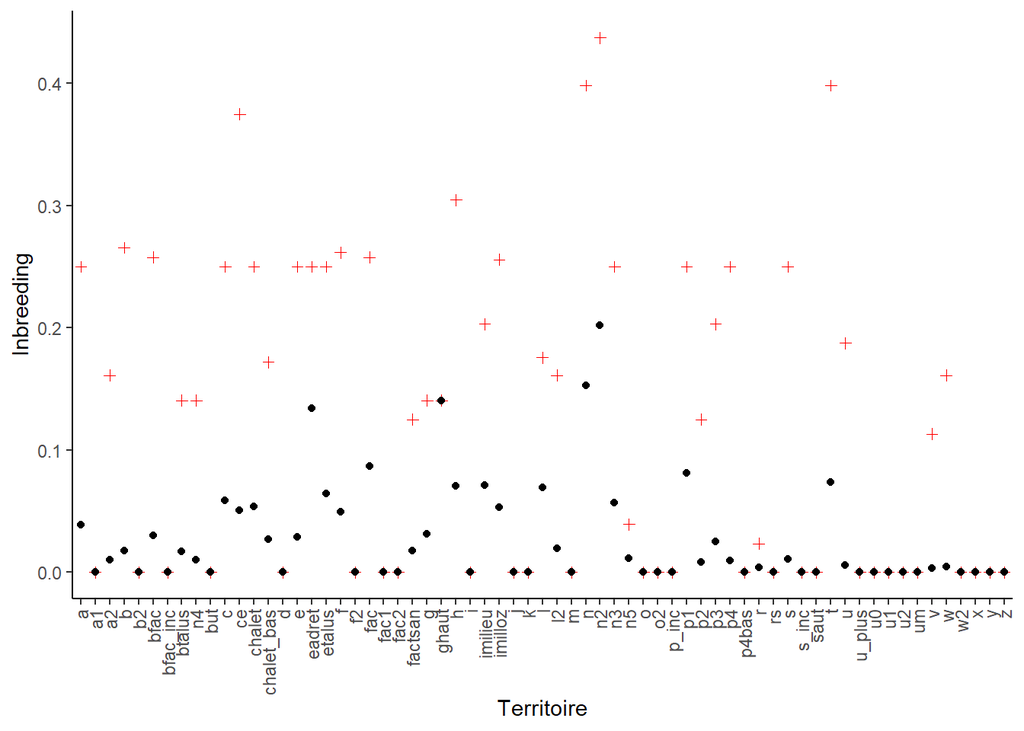

#### Sexe

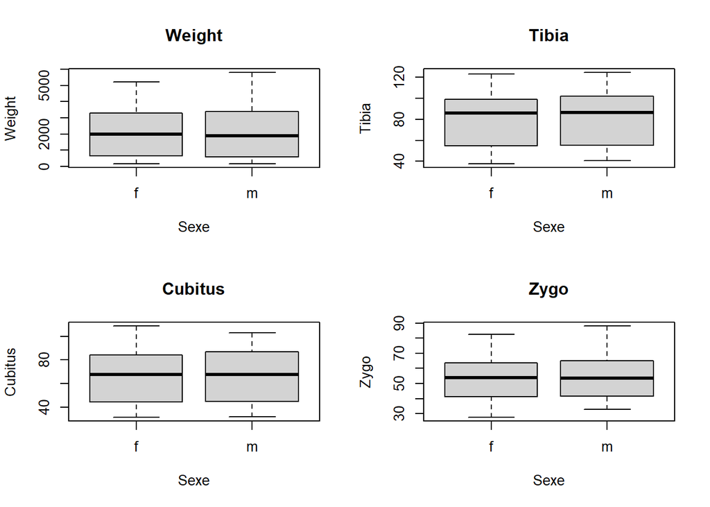

#### Year of birth

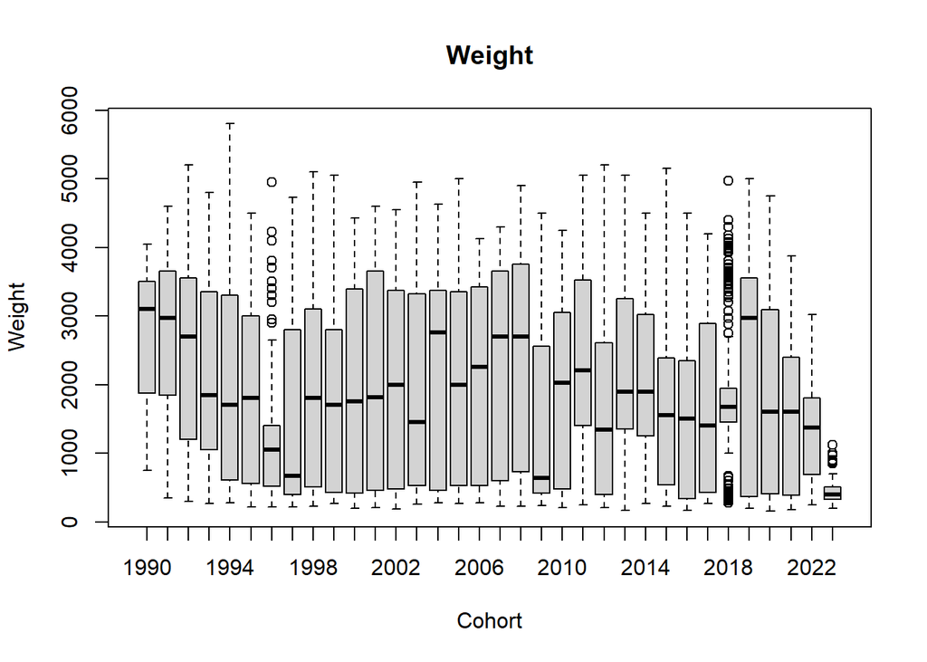

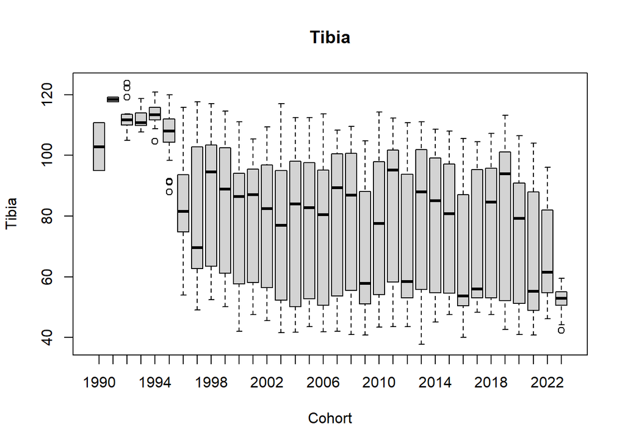

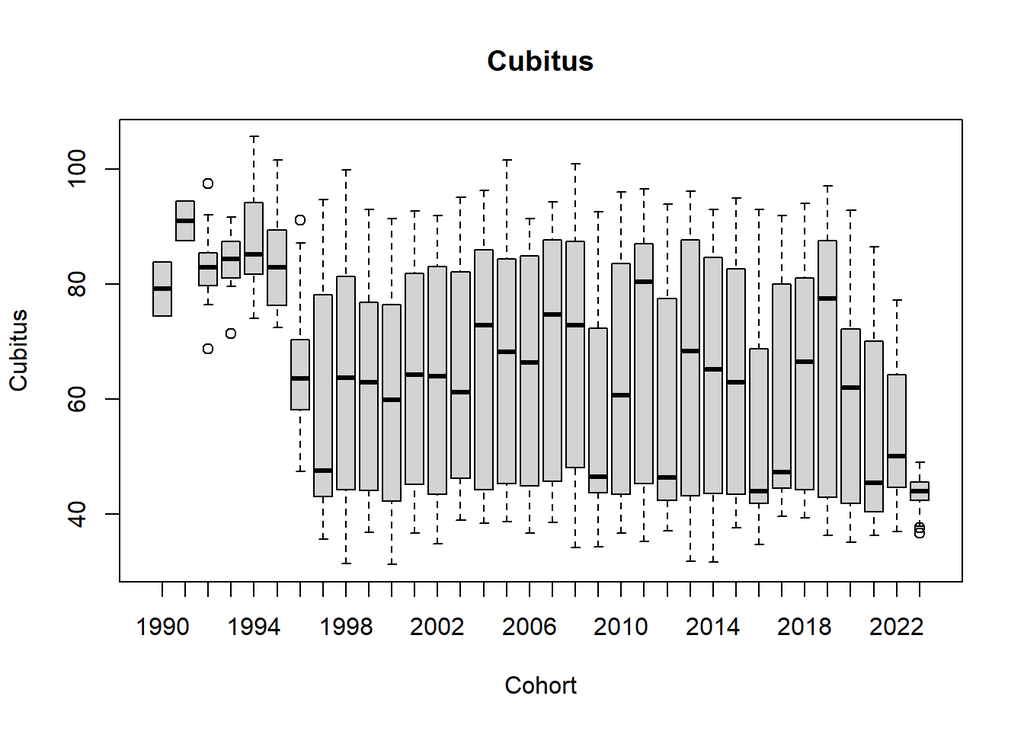

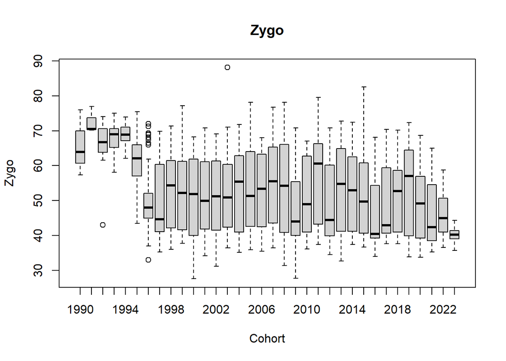

#### Year of capture

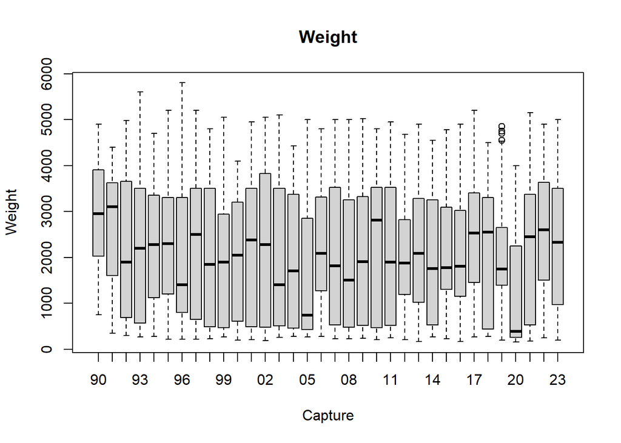

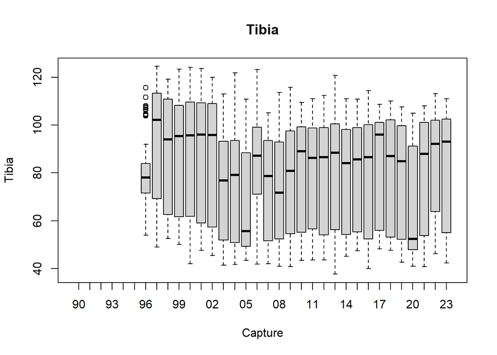

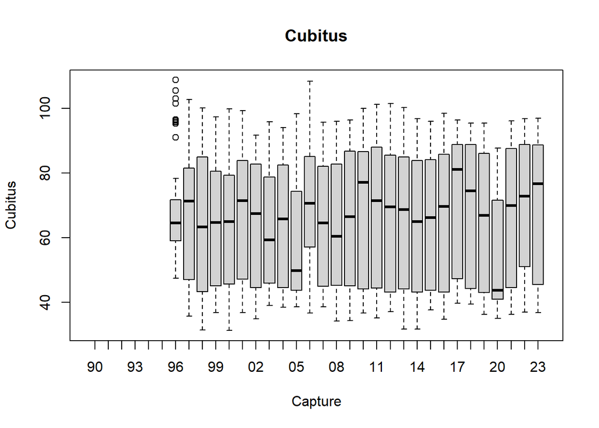

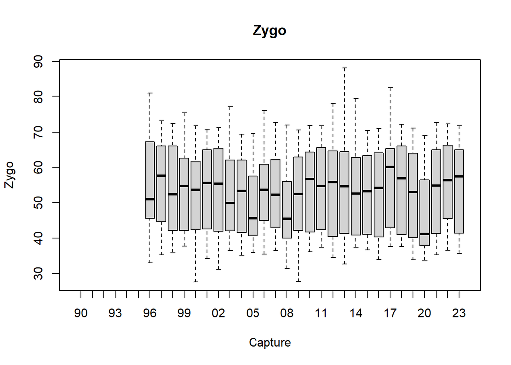

### **Social variables**

#### Sex ratio of subordinates at birth

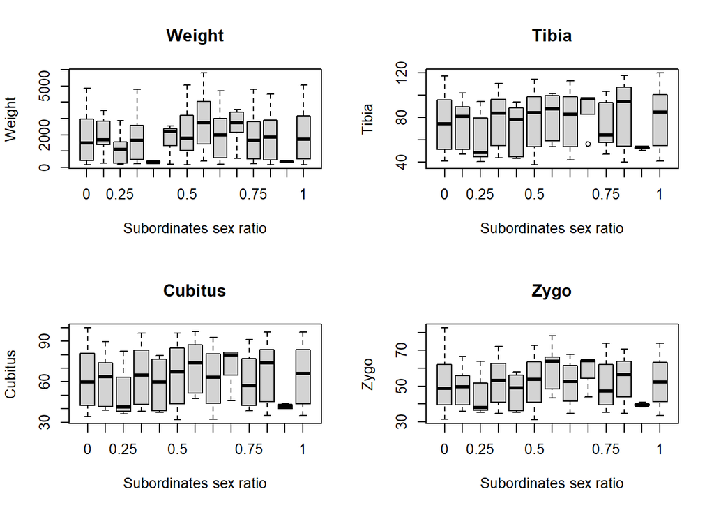

#### Litter size at birth

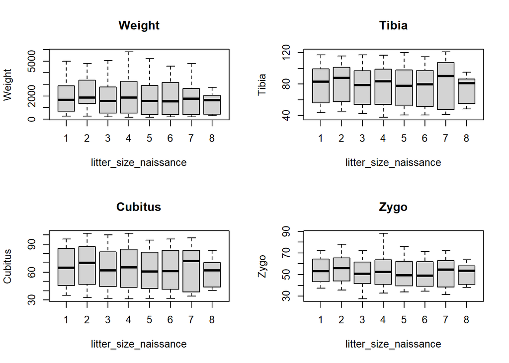

#### Number of subordinates at birth

**Quantitative**

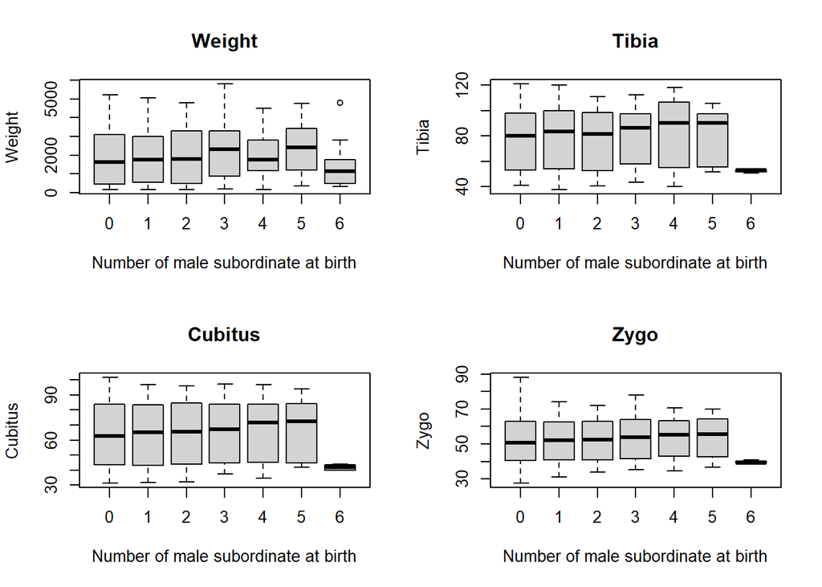

**Binary**

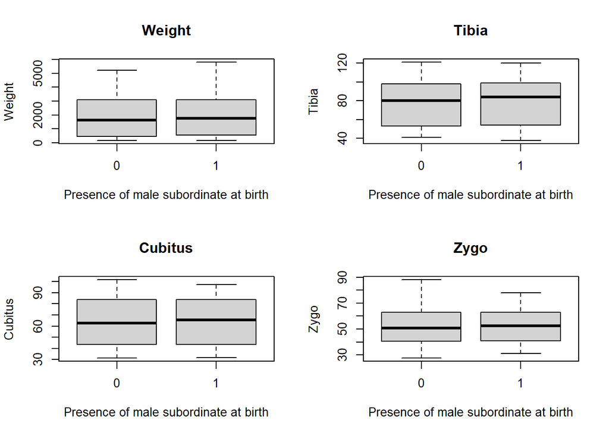

#### Group size and composition across years

**Mean group size per year per territory**

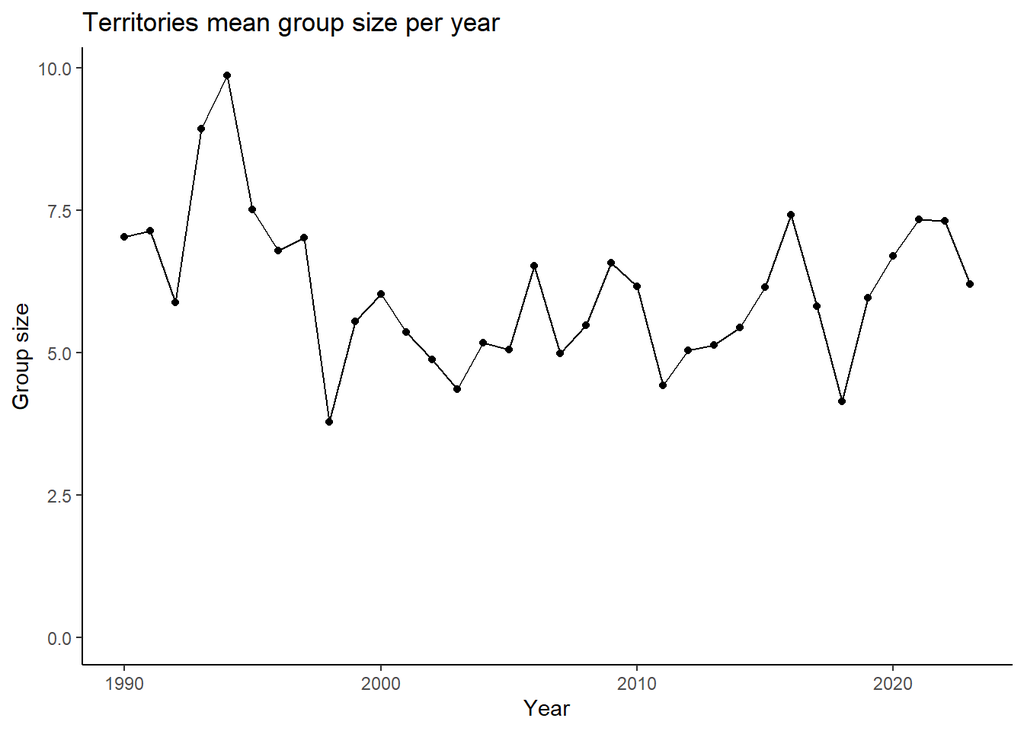

**Mean composition of age class per year per territory**

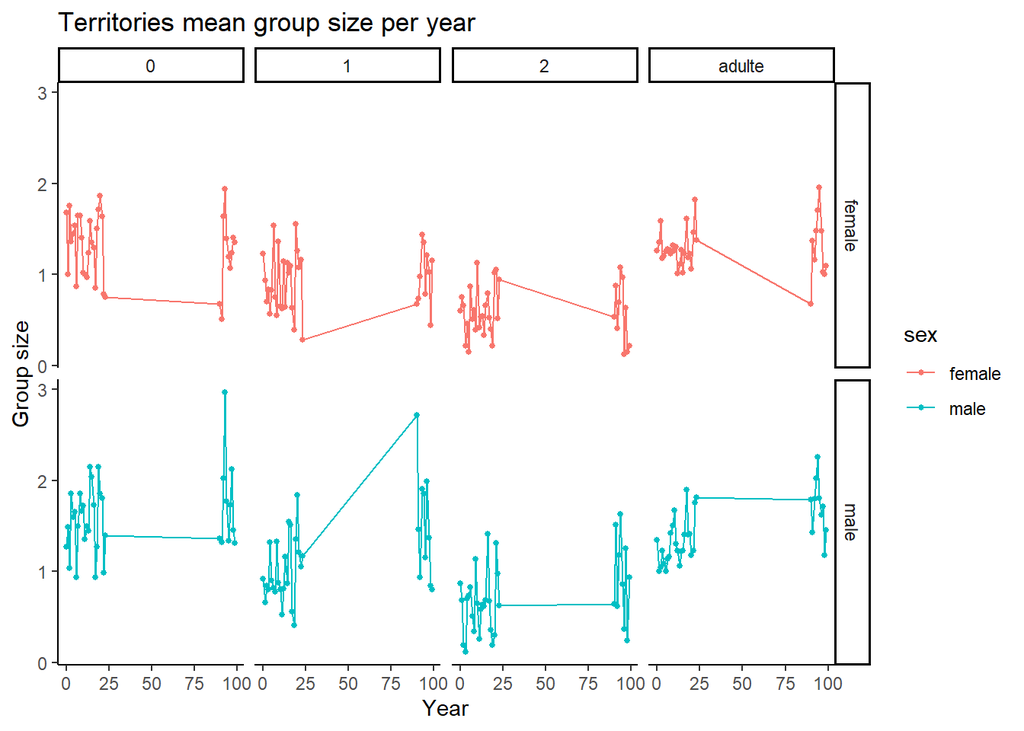

#### Dominance

**Size and mass of dominant individual**

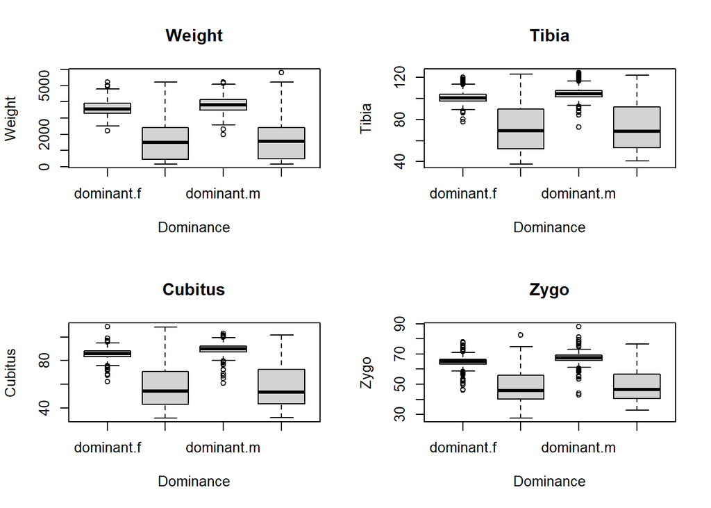

```r
par(mfrow = c(2, 2))
boxplot(pheno$masse ~ pheno$dominance * pheno$sexe, type = "p", xlab = "Dominance", ylab = "Weight", main = "Weight")
boxplot(pheno$tibia ~ pheno$dominance* pheno$sexe, type = "p", xlab = "Dominance", ylab = "Tibia", main = "Tibia")
boxplot(pheno$cubitus ~ pheno$dominance* pheno$sexe, type = "p", xlab = "Dominance", ylab = "Cubitus", main = "Cubitus")
boxplot(pheno$zygo ~ pheno$dominance* pheno$sexe, type = "p", xlab = "Dominance", ylab = "Zygo", main = "Zygo")
```

```r
par(mfrow = c(1, 1))
```

**% of dominant individual per age class**

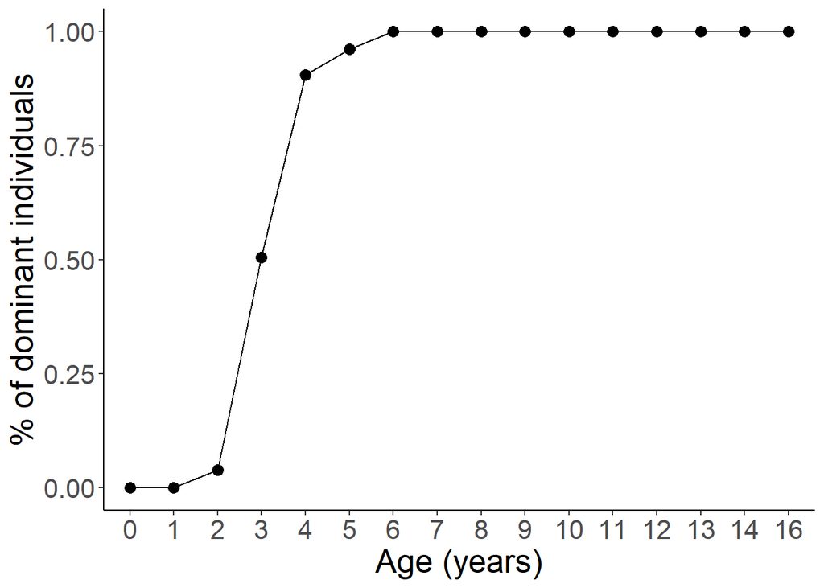

# **IDENTIFIABILITY OF PARAMETERS**

The idea here is to determine how many phenotype observations x non-NAs predictor available for each effect to calculate.

First, we filter the dataset with only non-NAs predictor values. As the response variable weight and size have almost no NAs, I decided to ignore it for visualization purpose and readability (i.e. to avoid representing each time results for wieght AND size).

```r
pheno_complete <- pheno[!is.na(pheno$annee_emergence) &
                      !is.na(pheno$age_emergence) &
                      !is.na(pheno$litter_size_naissance) &
                      !is.na(pheno$territoire) &
                      !is.na(pheno$taille_groupe_naissance),]
```

```
## [1] "TOTAL SAMPLE SIZE : 4678"
```

## I. Random effects

### Maternal effects

For the maternal effects, we need to consider :

- The number of repetition per mother
- The number of different partner they’ve had (number of half sibs)

#### Number of phenotype data with repeated mother

```r
# EXTRACT ID OF MOTHER WITH REPEATED MEASURES (>2)
mother_table <- table(pedigree_data$mother)
mother_repeated <- mother_table[mother_table > 1]
id_mother_repeated <- names(mother_repeated)
```

```r
paste0("NUMBER OF MOTHER WITH MORE THAN 1 OFFSPRING : ", length(id_mother_repeated), " (", round(length(id_mother_repeated) / length(unique(pedigree_data$mother)), 2)*100, "%)")
```

```
## [1] "NUMBER OF MOTHER WITH MORE THAN 1 OFFSPRING : 158 (96%)"
```

Now we’re determining the number of phenotype observation available for each mother with more than 1 offspring.

```r
rep_per_mother <-
  pheno_complete[pheno_complete$individual_id %in% id_mother_repeated, ] %>%
  group_by(individual_id) %>%
  summarise(n = n())

table(rep_per_mother$n)
```

```
##
##  3  4  5  6  7  8  9 10 11 12 13 14 16 18 21 24 31
##  6  8  2  7  9  9  7  8  6  5  3  2  3  3  1  1  1
```

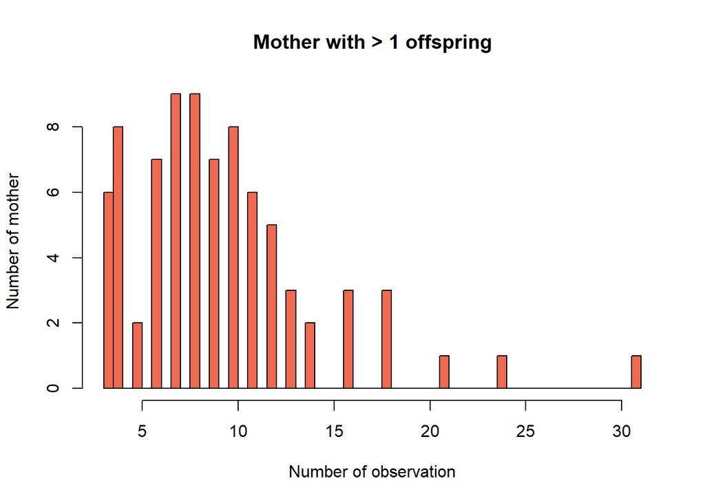

#### Number of phenotype data with mother with different partner

```r
# NUMBER OF UNIQUE PARTNER PER MOTHER
partner_per_mother <-
  pedigree_data %>%
  group_by(mother) %>%
  summarise(n = n_distinct(father)) %>%
  as.data.frame()

# EXTRACT ID OF MOTHER WITH SEVERAL PARTNERS
id_mother_partner_repeated <- partner_per_mother$mother[partner_per_mother$n > 1]

table(partner_per_mother$n)
```

```
##
##   1   2   3   4
## 110  36  17   1
```

```
## [1] "NUMBER OF MOTHER WITH MORE THAN 1 PARTNER : 54 (33%)"
```

```r
# NUMBER OF OBSERVATIONS PER MOTHER WITH SEVERAL PARTNER
rep_per_mother_partner <-
  pheno_complete[pheno_complete$individual_id %in% id_mother_partner_repeated, ] %>%
  group_by(individual_id) %>%
  summarise(n = n())

table(rep_per_mother_partner$n)
```

```
##
##  6  7  8  9 10 11 12 13 14 16 18
##  5  1  4  2  5  1  3  1  2  3  1
```

The table is interpreted as *row number* repetition of mother with more than one partner associated with *column number* of observations.

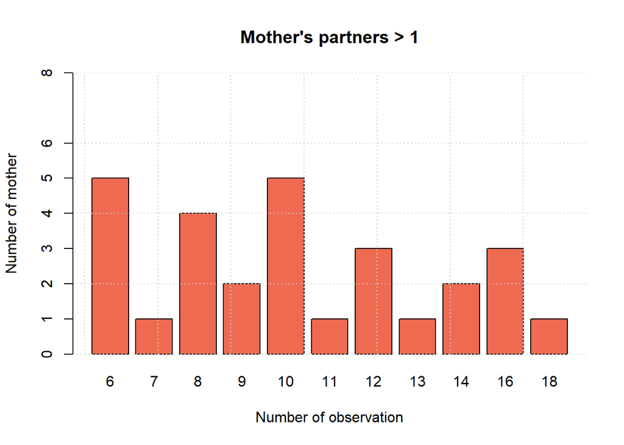

### Individual ID

We’ll compute here the number of phenotype observation per unique individual.

```r
# NUMBER OF OBSERVATION PER INDIVIDUAL
rep_individual <- table(pheno_complete$individual_id)

# REPARTITION OF THE NUMBER OF REPETITIONS
table(rep_individual)
```

```
## rep_individual
##   1   2   3   4   5   6   7   8   9  10  11  12  13  14  15  16  17  18  19  20
## 649 180 138 113  72  63  54  35  22  20  21  14   9   4   1   5   3   3   2   1
##  21  22  24  25  31  35
##   2   1   1   1   1   1
```

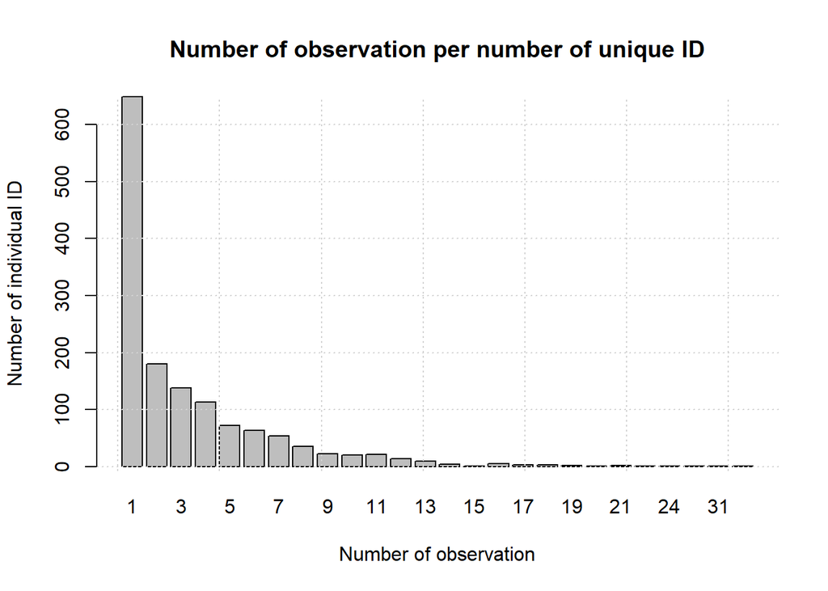

### Cohorts

```r
sample_birth_year <- table(pheno_complete$annee_emergence)
sample_birth_year
```

```
##
## 1990 1991 1992 1993 1994 1995 1996 1997 1998 1999 2000 2001 2002 2003 2004 2005
##   10   17   80   83   75  115   81   57   88   61   64   53   67   87  112  132
## 2006 2007 2008 2009 2010 2011 2012 2013 2014 2015 2016 2017 2018 2019 2020 2021
##   65  140  160  117  165  202  168  292  395  312  177  115  311  246  203  208
## 2022 2023
##  124   96
```

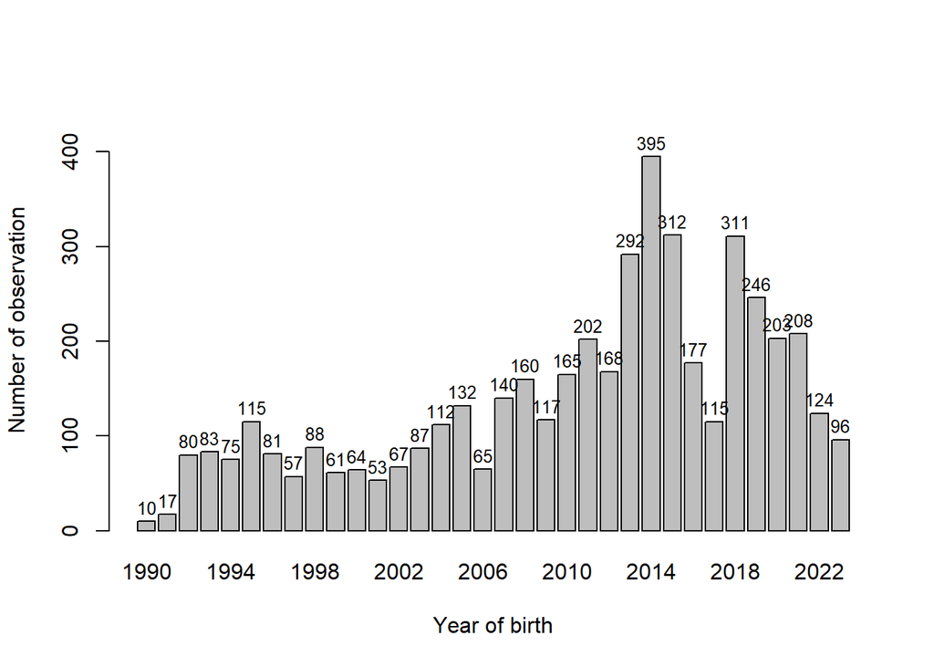

### Capture year

```r
sample_capture_year <- table(pheno_complete$annee_capture)
sample_capture_year
```

```
##
##  90  91  92  93  94  95  96  97  98  99  00  01  02  03  04  05  06  07  08  09
##   1   7  25  54  79 104 101  83  53  68  64  63  51  63  78  63  81  91  95 133
##  10  11  12  13  14  15  16  17  18  19  20  21  22  23
## 133 141 211 191 296 310 356 204 175 385  94 278 202 345
```

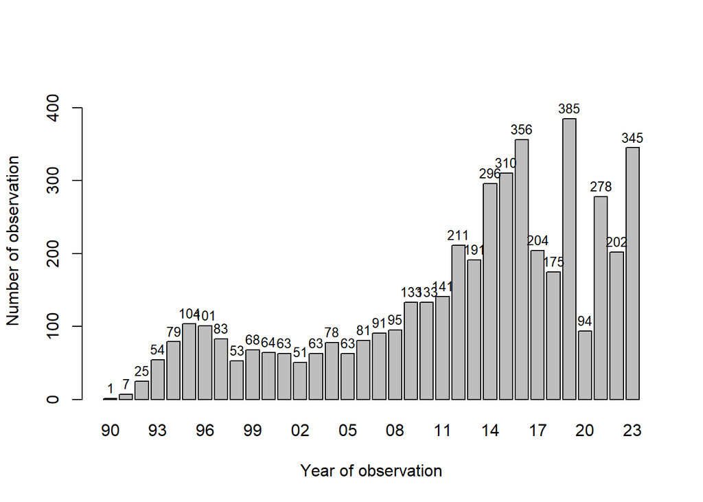

We notice few observation in the first year. It is explained by the fact that emergence date were not available and compute as “NA”. As a result, a lot of observation from these years have been excluded from the analysis.

### Territory

#### Per territory

```r
# NUMBER OF OBSERVATION PER TERRITORY
sample_territories <- table(pheno$territoire)
sample_territories <- sample_territories[order(sample_territories, decreasing = T)]  # sorting
```

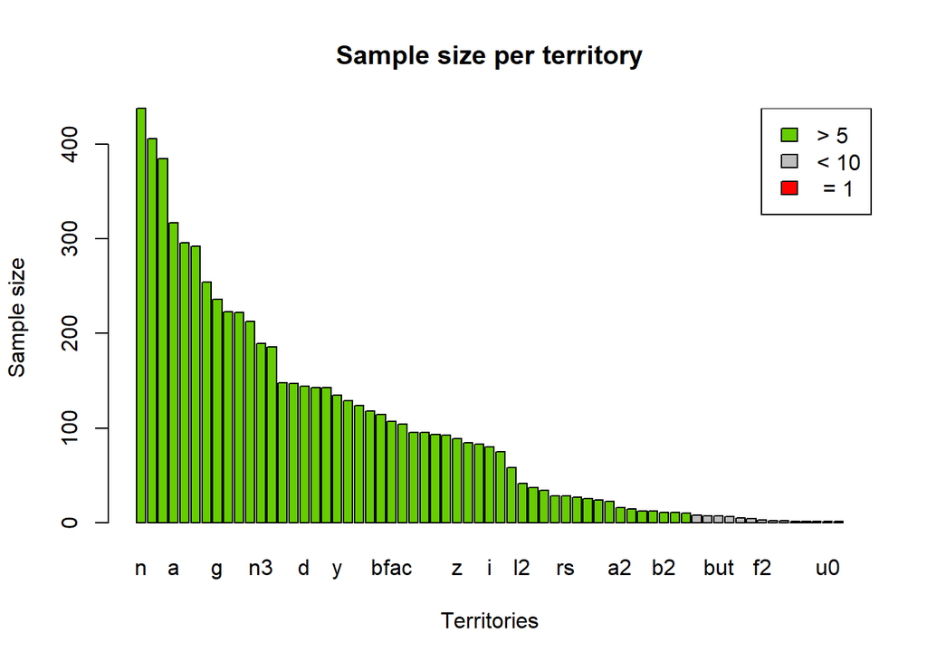

#### Per territory per year

```r
territory_per_year <- pheno_complete %>%
  group_by(territoire, annee_territoire) %>%
  summarise(n = n())

table(territory_per_year$n)
```

```
##
##  1  2  3  4  5  6  7  8  9 10 11 12 13 14 15 16 17 18 19 20 21 22 23 24 25 27
## 61 60 56 64 59 58 40 33 24 22 22 18 13 12  9  9  9  7  5  7  3  5  3  1  1  3
## 28 30 32 33 34 48 51 52
##  2  5  1  1  2  1  1  1
```

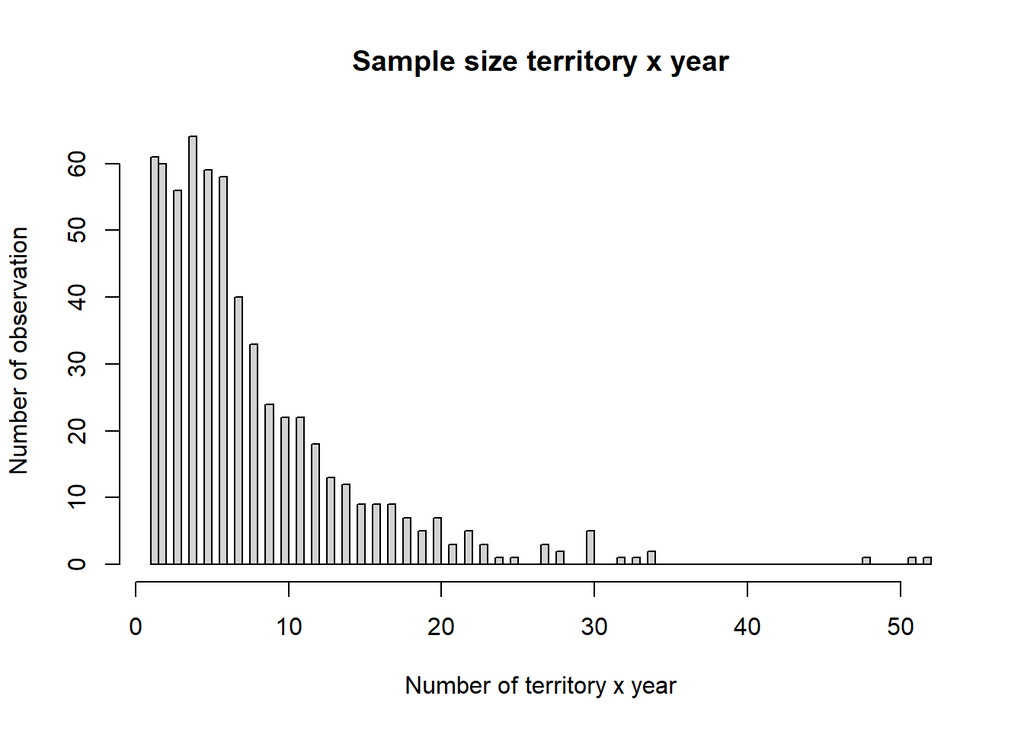

# **OBSERVER BIAS**

Observers have only been reported since 2013. We first check if there’s any observer effect during this period.

### Testing for presence of bias in size

```r
# NUMBER OF MEASURES PER OBSERVERS
observer_sample <- pheno_complete[pheno_complete$annee_capture %in% 13:23 & !is.na(pheno_complete$tibia),] %>%
  group_by(operateur_id) %>%
  summarise(n = n()) %>%
  arrange(desc(n))

observer_sample
```

| operateur_id | n |
| --- | --- |
| 5 | 878 |
| 2 | 491 |
| 22 | 153 |
| 24 | 64 |
| 21 | 52 |
| 20 | 47 |
| 18 | 24 |
| 1 | 22 |
| 4 | 6 |
| 17 | 6 |

[output cut: 2 more lines]

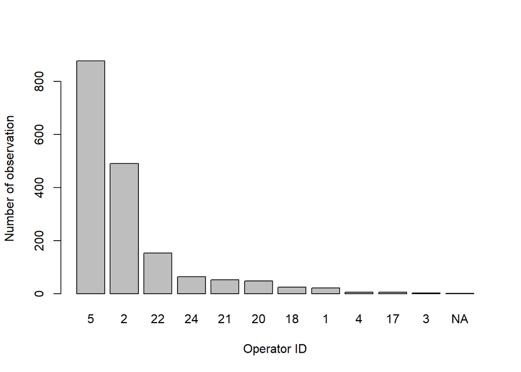

To check observer bias, we will only select the operator that have measured more than 200 individuals, the other will be NAs.

```r
# EXTRACT MAIN OBSERVER
main_observer <- unlist(observer_sample[observer_sample$n > 200, "operateur_id"])

# OTHER OBSERVER AS A DUMMY VARIABLE "NA"
pheno_complete[is.na(pheno_complete$operateur_id), "operateur_id"] <- "NA"  # NA as level of factor
pheno_complete$operateur_id <- as.factor(pheno_complete$operateur_id)
pheno_complete$operateur_id <-
  pheno_complete$operateur_id %>%
  fct_collapse("NA" = unlist(pheno_complete[!pheno_complete$operateur_id %in% main_observer, "operateur_id"]))

# FILTER DATAFRAME after 2013
data_main_observer <- pheno_complete[as.numeric(as.character(pheno_complete$annee_capture)) >=13,]
```

```r
data_main_observer %>%
  group_by(operateur_id) %>%
  summarise(
    median_age = median(age_emergence),
    quantile_25 = quantile(age_emergence, probs = .25),
    quantile_75 = quantile(age_emergence, probs = .75),
    n = n()
  )
```

| operateur_id | median_age | quantile_25 | quantile_75 | n |
| --- | --- | --- | --- | --- |
| NA | 332 | 292.25 | 692 | 1938 |
| 2 | 313 | 1.00 | 690 | 500 |
| 5 | 322 | 2.00 | 712 | 973 |

Here, the difficulty is to check if there’s a structure of manipulation, for example, everything is good if operators measure individuals randomly, but if some operators tends to only measures the pups, it will be difficult to evaluate a potential observer effect. To test observer effect, we’ll only consider the main operators and select individuals that have been measured several times by several operators. We’ll consider the response variable ‘size’ for individuals with > 4 years old (i.e. with terminated growth).

**Extract individuals measured per all observers and > 4 years old**

```r
repeated_measured_individual <-
  data_main_observer[data_main_observer$operateur_id != "NA",] %>%
  filter(age_emergence > 4*365) %>%
  group_by(individual_id, operateur_id) %>%
  summarise(n = n())

repeated_individual_id <-  names(which(table(repeated_measured_individual$individual_id) > 1))
```

**Plot size per operator**  
Note that we only plot the size of individuals >= 4 years old and measured by all operators. Each measure represent one individual which has attain its full growth. Therefore, the variance observed corresponds to the error of measure.

```r
# DATA WITH AGE > 4
data_main_observer <-
  data_main_observer %>%
  filter(age_emergence > 365*4 & operateur_id %in% main_observer)

# MEASURED BY BOTH OBSERVER
data_main_observer <- data_main_observer[data_main_observer$individual_id %in% repeated_individual_id,]
```

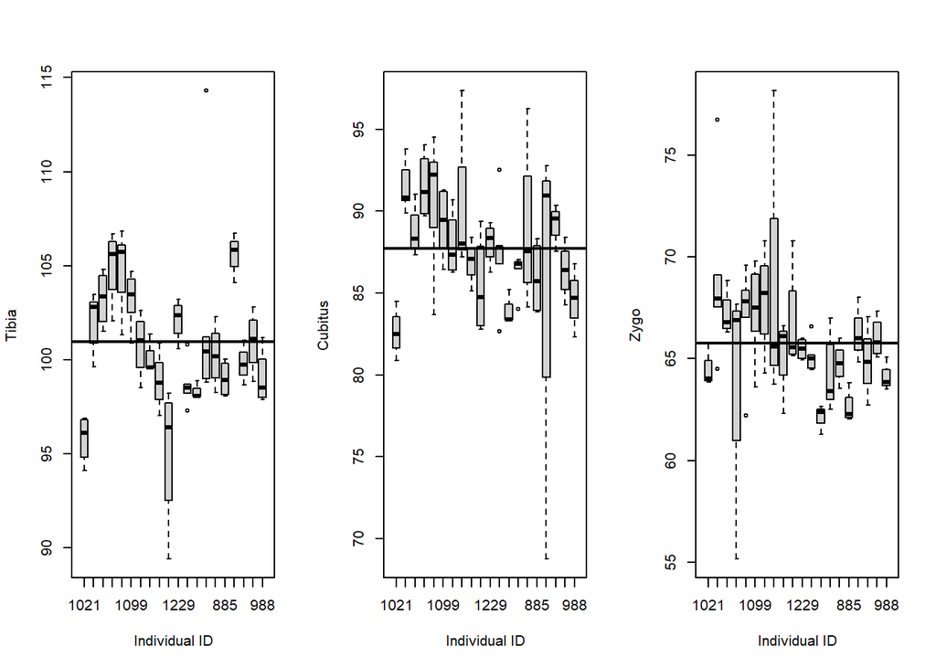

**Modelisation of partial residuals**  
We construct a constant model with individual ID as random effects. Then, we plot the residuals against the operator IDs to see which one tends to overestimate or underestimate the measure.

```r
# REMOVING NAs
data_mod <- data_main_observer[!is.na(data_main_observer$tibia) &
                                 !is.na(data_main_observer$operateur_id),]

# CONSTANT MODEL
mod <- lme4::lmer(formula = log(tibia) ~ 1 + (1|individual_id), data = data_mod)
summary(mod)
```

```
## Linear mixed model fit by REML ['lmerMod']
## Formula: log(tibia) ~ 1 + (1 | individual_id)
##    Data: data_mod
##
## REML criterion at convergence: -347.3
##
## Scaled residuals:
##     Min      1Q  Median      3Q     Max
## -3.0837 -0.4762 -0.0637  0.5426  4.9368
##
## Random effects:
##  Groups        Name        Variance  Std.Dev.
##  individual_id (Intercept) 0.0006717 0.02592
##  Residual                  0.0005271 0.02296
## Number of obs: 83, groups:  individual_id, 20
##
## Fixed effects:
##             Estimate Std. Error t value
## (Intercept) 4.612445   0.006341   727.4
```

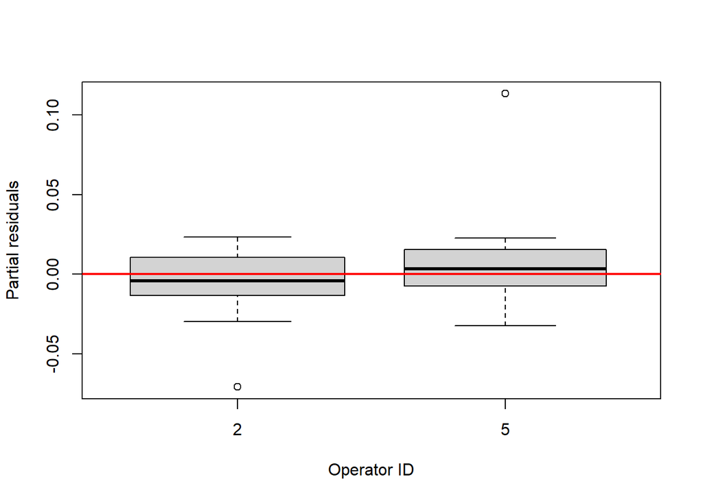